# Replication initiation protein

Fold-switch pair **2z9oB_1repC** — **2z9oB** vs **1repC**

Escherichia coli K-12 / Escherichia coli

## Figure 1: Phylogenetic tree with per-cluster fold-preference heatmap.

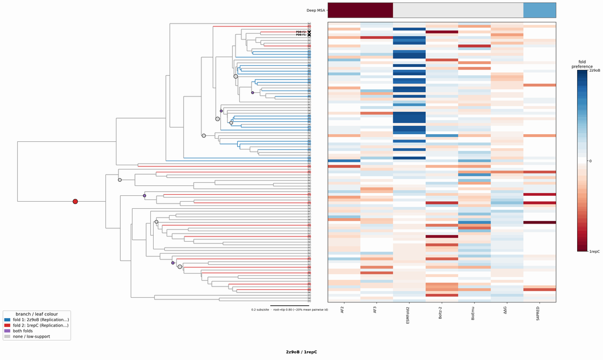

## Figure 2: Aligned overlay (both folds superposed)

The single fold-switching chain of each fold superposed by TM-align; waters hidden, any ligand shown as green sticks. Grey = structurally conserved core, colour = divergent (fold-switching) region. This pair switches fold coupled to oligomerisation; a single protomer is shown, not the full assembly.

2z9oB (Replication initiation protein) · tetramer1repC (Replication initiation protein) · trimer

TM-score: 0.594 · Trigger class: oligomerization

Aligned overlay

Loading...

## Figure 3: The two folds, side by side

Each fold is coloured by per-residue Cα deviation between the two superposed structures: grey ≈ conserved core, full colour = structurally divergent (fold-switching) region.

2z9oB (Replication initiation protein)

1repC (Replication initiation protein)

0 Å5≥10 Å

2z9oB (Replication initiation protein)

Loading...

1repC (Replication initiation protein)

Loading...

## Figure 4: Best-cluster predicted contact maps over the two true folds.

Predicted contact maps (MSA-Transformer) for the clusters best matching each fold, over the true contacts of fold 1 (upper triangle) and fold 2 (lower). Divergent contacts between clusters are the contact-level signature of fold-switching.

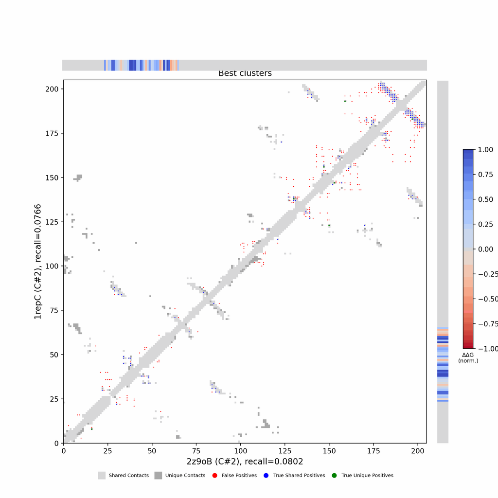

## Figure 5: Per-residue ΔΔG fold-preference contribution

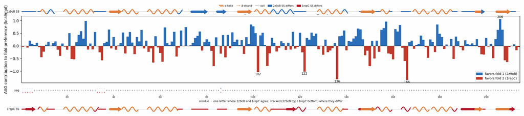

**More figures**

## Figure 6: Deep-MSA contact map panel / Best clusters contact map panel

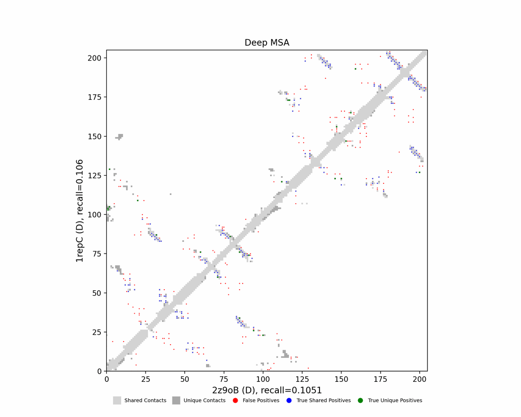

Deep-MSA contact map panel

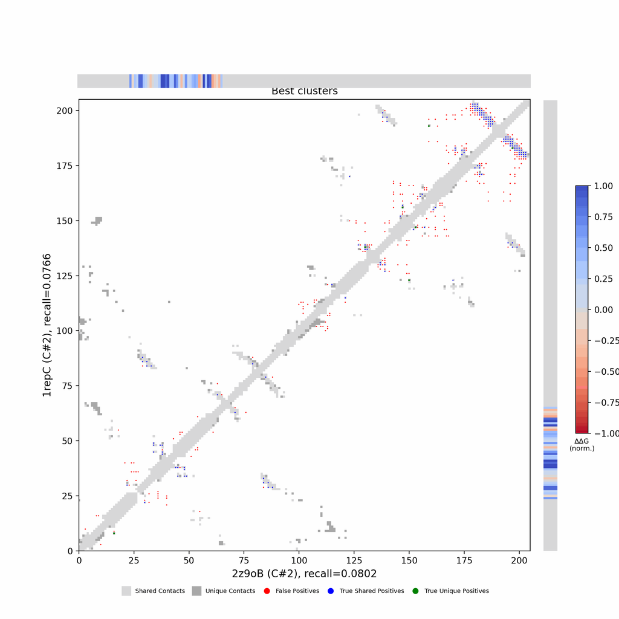

Best clusters contact map panel

## Figure 7: All clusters contact-map mosaic (small multiples).

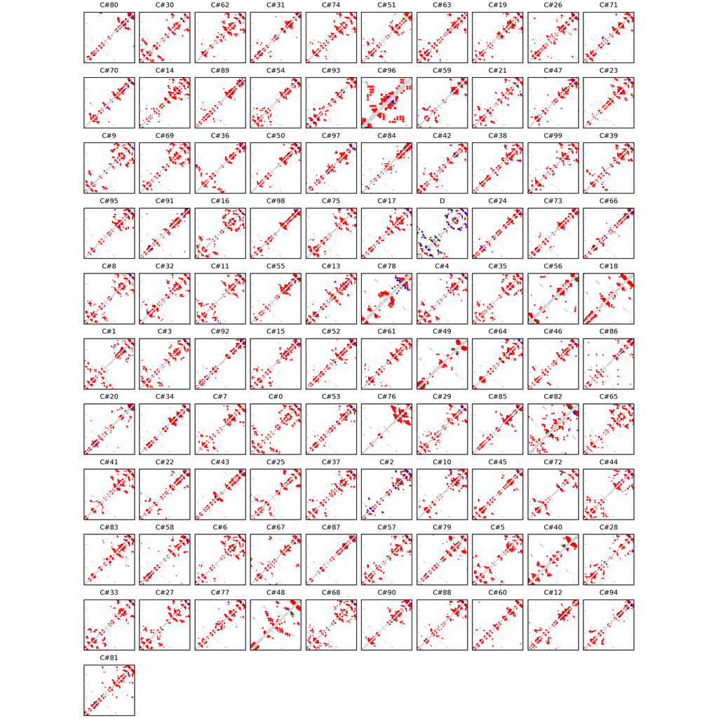

## Figure 8: Phylo null: tree with shuffled cluster fold labels.

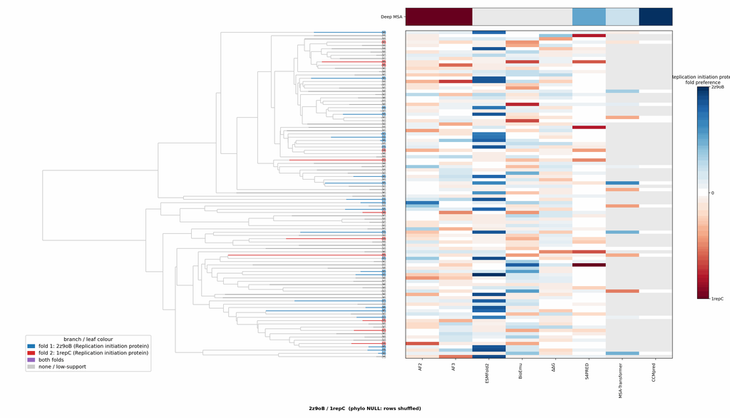

## Cluster metrics table

Per-cluster metrics underlying the figures above.

| cluster | n | neff | AF2_TM1 | AF2_TM2 | AF3_TM1 | AF3_TM2 | RE-MSAT-COM | RE-MSAT1 | RE-MSAT2 | ESM_SEQIDS | ESM_TM1 | ESM_TM2 | ΔΔG_Bias | ΔΔG_Bias_std | ΔΔG_frac_F1 | Boltz2_pref | S4PRED_pref | CCMpred_pref | BioEmu_pref |
| --- | --- | --- | --- | --- | --- | --- | --- | --- | --- | --- | --- | --- | --- | --- | --- | --- | --- | --- | --- |
| Deep | - | - | 0.63 | 0.89 | 0.62 | 0.98 | 0.44 | 0.45 | 0.44 | - | - | - | - | - | - | - | 0.03 | 0.01 | - |
| 000 | 206.0 | 127.0 | 0.56 | 0.63 | 0.47 | 0.46 | 0.01 | 0.02 | 0.01 | 007; 007; 004; 004; 001; 008; 006; 001; 008; 006 | 0.47 ± 0.03 | 0.57 ± 0.14 | 16.51 | 6.02 | 1.0 | -0.03 | 0.03 | 0.0 | -0.06 |
| 001 | 182.0 | 88.0 | 0.26 | 0.27 | 0.55 | 0.54 | 0.02 | 0.02 | 0.02 | 005; 005; 001; 003; 001; 003; 006; 002; 002; 006 | 0.57 ± 0.01 | 0.80 ± 0.02 | 13.04 | 6.08 | 1.0 | -0.04 | 0.02 | 0.0 | -0.02 |
| 002 | 134.0 | 35.0 | 0.44 | 0.45 | 0.5 | 0.5 | 0.3 | 0.25 | 0.21 | 006; 006; 001; 001; 002; 002; 004; 010; 004; 010 | 0.61 ± 0.05 | 0.76 ± 0.07 | 11.3 | 7.78 | 0.9 | -0.19 | 0.03 | 0.0 | -0.03 |
| 003 | 100.0 | 51.0 | 0.36 | 0.38 | 0.55 | 0.63 | 0.04 | 0.04 | 0.02 | 001; 002; 003; 002; 001; 003; 007; 007; 006; 008 | 0.58 ± 0.02 | 0.81 ± 0.04 | 14.33 | 5.31 | 1.0 | -0.02 | 0.03 | 0.0 | -0.03 |
| 004 | 84.0 | 51.0 | 0.41 | 0.41 | 0.49 | 0.56 | 0.03 | 0.03 | 0.02 | 003; 003; 004; 005; 009; 005; 009; 004; 001; 002 | 0.58 ± 0.01 | 0.75 ± 0.05 | 13.1 | 4.59 | 1.0 | -0.03 | 0.02 | 0.0 | -0.04 |
| 005 | 73.0 | 48.0 | 0.43 | 0.45 | 0.47 | 0.5 | 0.0 | 0.0 | 0.0 | 002; 002; 004; 004; 003; 003; 001; 001; 007; 006 | 0.59 ± 0.02 | 0.76 ± 0.04 | 12.88 | 6.87 | 0.9 | -0.05 | 0.02 | 0.0 | -0.02 |
| 006 | 68.0 | 34.0 | 0.44 | 0.44 | 0.42 | 0.42 | 0.01 | 0.02 | 0.01 | 002; 003; 003; 002; 001; 004; 001; 004; 009; 007 | 0.58 ± 0.01 | 0.80 ± 0.03 | 12.69 | 5.26 | 1.0 | -0.0 | 0.03 | 0.0 | -0.0 |
| 007 | 65.0 | 17.0 | 0.52 | 0.43 | 0.43 | 0.42 | 0.01 | 0.01 | 0.01 | 001; 001; 002; 002; 003; 003; 008; 006; 005; 005 | 0.57 ± 0.02 | 0.81 ± 0.04 | 18.88 | 4.05 | 1.0 | 0.0 | 0.03 | 0.0 | -0.02 |
| 008 | 63.0 | 25.0 | 0.51 | 0.52 | 0.5 | 0.52 | 0.04 | 0.03 | 0.02 | 003; 003; 001; 005; 001; 005; 002; 002; 004; 004 | 0.58 ± 0.01 | 0.73 ± 0.05 | 17.02 | 5.92 | 1.0 | -0.01 | 0.03 | 0.0 | -0.03 |
| 009 | 57.0 | 37.0 | 0.42 | 0.41 | 0.47 | 0.44 | 0.05 | 0.04 | 0.03 | 002; 003; 007; 007; 003; 002; 004; 004; 001; 001 | 0.59 ± 0.01 | 0.77 ± 0.03 | 14.44 | 6.7 | 1.0 | 0.01 | 0.03 | 0.0 | -0.02 |
| 010 | 53.0 | 16.0 | 0.53 | 0.44 | 0.55 | 0.56 | 0.03 | 0.02 | 0.02 | 001; 003; 001; 003; 004; 002; 005; 004; 005; 002 | 0.57 ± 0.00 | 0.80 ± 0.03 | 17.34 | 5.76 | 1.0 | -0.14 | 0.03 | 0.0 | -0.02 |
| 011 | 53.0 | 26.0 | 0.34 | 0.39 | 0.44 | 0.42 | 0.04 | 0.03 | 0.03 | 004; 008; 004; 008; 005; 005; 006; 006; 001; 001 | 0.49 ± 0.04 | 0.59 ± 0.15 | 15.22 | 4.15 | 1.0 | 0.01 | 0.03 | 0.0 | -0.05 |
| 012 | 53.0 | 11.0 | 0.46 | 0.42 | 0.42 | 0.48 | 0.01 | 0.01 | 0.01 | 007; 007; 002; 003; 004; 004; 003; 002; 001; 001 | 0.58 ± 0.01 | 0.76 ± 0.01 | 14.08 | 3.13 | 1.0 | -0.01 | 0.03 | 0.0 | 0.01 |
| 013 | 52.0 | 23.0 | 0.47 | 0.48 | 0.46 | 0.45 | 0.02 | 0.01 | 0.02 | 005; 005; 010; 010; 003; 003; 002; 002; 001; 001 | 0.46 ± 0.01 | 0.49 ± 0.01 | 12.78 | 5.3 | 1.0 | -0.01 | 0.03 | 0.0 | -0.02 |
| 014 | 52.0 | 25.0 | 0.64 | 0.73 | 0.67 | 0.68 | 0.0 | 0.01 | 0.0 | 004; 005; 005; 004; 001; 002; 006; 002; 001; 006 | 0.59 ± 0.00 | 0.77 ± 0.02 | 8.77 | 4.43 | 1.0 | -0.01 | 0.03 | 0.0 | -0.02 |
| 015 | 52.0 | 23.0 | 0.42 | 0.41 | 0.44 | 0.51 | 0.01 | 0.01 | 0.01 | 001; 002; 004; 002; 001; 004; 003; 003; 006; 006 | 0.59 ± 0.02 | 0.76 ± 0.04 | 15.56 | 4.59 | 1.0 | -0.05 | 0.03 | 0.0 | -0.02 |
| 016 | 51.0 | 42.0 | 0.68 | 0.5 | 0.5 | 0.51 | 0.03 | 0.03 | 0.03 | - | - | - | 19.38 | 5.28 | 1.0 | 0.02 | 0.03 | - | 0.01 |
| 017 | 50.0 | 16.0 | 0.44 | 0.44 | 0.64 | 0.62 | 0.04 | 0.03 | 0.03 | - | - | - | 12.23 | 6.31 | 1.0 | -0.06 | 0.02 | - | -0.04 |
| 018 | 49.0 | 29.0 | 0.21 | 0.22 | 0.44 | 0.45 | 0.0 | 0.07 | 0.0 | - | - | - | 8.4 | 2.65 | 1.0 | -0.01 | 0.02 | - | -0.01 |
| 019 | 48.0 | 31.0 | 0.61 | 0.71 | 0.72 | 0.98 | 0.02 | 0.02 | 0.02 | - | - | - | 9.15 | 3.6 | 1.0 | -0.01 | 0.03 | - | -0.01 |
| 020 | 48.0 | 5.0 | 0.4 | 0.44 | 0.46 | 0.49 | 0.08 | 0.06 | 0.04 | - | - | - | 16.15 | 3.12 | 1.0 | 0.03 | 0.02 | - | -0.04 |
| 021 | 47.0 | 21.0 | 0.46 | 0.51 | 0.52 | 0.54 | 0.01 | 0.01 | 0.01 | - | - | - | 17.61 | 4.69 | 1.0 | -0.06 | 0.03 | - | -0.0 |
| 022 | 47.0 | 9.0 | 0.46 | 0.47 | 0.47 | 0.51 | 0.03 | 0.03 | 0.02 | - | - | - | 17.18 | 4.18 | 1.0 | -0.04 | 0.03 | - | -0.0 |
| 023 | 47.0 | 16.0 | 0.72 | 0.63 | 0.48 | 0.5 | 0.02 | 0.02 | 0.01 | - | - | - | 10.11 | 6.36 | 1.0 | 0.0 | 0.03 | - | -0.02 |
| 024 | 46.0 | 7.0 | 0.42 | 0.45 | 0.48 | 0.46 | 0.0 | 0.0 | 0.0 | - | - | - | 4.85 | 4.88 | 0.9 | -0.04 | 0.03 | - | -0.02 |
| 025 | 46.0 | 12.0 | 0.41 | 0.45 | 0.55 | 0.57 | 0.0 | 0.0 | 0.0 | - | - | - | 16.61 | 4.16 | 1.0 | -0.06 | 0.03 | - | -0.01 |
| 026 | 46.0 | 13.0 | 0.25 | 0.26 | 0.54 | 0.6 | 0.03 | 0.03 | 0.02 | - | - | - | 12.72 | 4.65 | 1.0 | -0.0 | 0.03 | - | -0.0 |
| 027 | 45.0 | 29.0 | 0.47 | 0.46 | 0.49 | 0.46 | 0.03 | 0.03 | 0.02 | - | - | - | 13.58 | 5.13 | 1.0 | -0.05 | 0.03 | - | -0.02 |
| 028 | 44.0 | 15.0 | 0.38 | 0.43 | 0.54 | 0.58 | 0.01 | 0.01 | 0.01 | - | - | - | 15.26 | 5.2 | 1.0 | -0.01 | 0.02 | - | -0.01 |

[output cut: 71 more lines]